```python
import numpy as np
import pandas as pd
import matplotlib.pyplot as plt
pd.set_option('display.notebook_repr_html', True)
import warnings;
warnings.simplefilter('ignore')
```

# Information From Kaggle Data

Relevant Information: The dataset contains cases from a study that was conducted between 1958 and 1970 at the University of Chicago's Billings Hospital on the survival of patients who had undergone surgery for breast cancer.

Number of Instances: 306

Number of Attributes: 4 (including the class attribute)

Attribute Information:

```
Age of patient at time of operation (numerical)
Patient's year of operation (year - 1900, numerical)
Number of positive axillary nodes detected (numerical)
Survival status (class attribute) 1 = the patient survived 5 years or longer 2 = the patient died within 5 year
```

```python
haberman_data_raw = pd.read_csv("haberman.csv",header = None)
haberman_data_raw # Contains no Columns Labels
```

|  | 0 | 1 | 2 | 3 |
| --- | --- | --- | --- | --- |
| 0 | 30 | 64 | 1 | 1 |
| 1 | 30 | 62 | 3 | 1 |
| 2 | 30 | 65 | 0 | 1 |
| 3 | 31 | 59 | 2 | 1 |
| 4 | 31 | 65 | 4 | 1 |
| 5 | 33 | 58 | 10 | 1 |
| 6 | 33 | 60 | 0 | 1 |
| 7 | 34 | 59 | 0 | 2 |
| 8 | 34 | 66 | 9 | 2 |
| 9 | 34 | 58 | 30 | 1 |
| 10 | 34 | 60 | 1 | 1 |
| 11 | 34 | 61 | 10 | 1 |
| 12 | 34 | 67 | 7 | 1 |
| 13 | 34 | 60 | 0 | 1 |
| 14 | 35 | 64 | 13 | 1 |
| 15 | 35 | 63 | 0 | 1 |
| 16 | 36 | 60 | 1 | 1 |
| 17 | 36 | 69 | 0 | 1 |
| 18 | 37 | 60 | 0 | 1 |
| 19 | 37 | 63 | 0 | 1 |
| 20 | 37 | 58 | 0 | 1 |
| 21 | 37 | 59 | 6 | 1 |
| 22 | 37 | 60 | 15 | 1 |
| 23 | 37 | 63 | 0 | 1 |
| 24 | 38 | 69 | 21 | 2 |
| 25 | 38 | 59 | 2 | 1 |
| 26 | 38 | 60 | 0 | 1 |
| 27 | 38 | 60 | 0 | 1 |
| 28 | 38 | 62 | 3 | 1 |
| 29 | 38 | 64 | 1 | 1 |
| ... | ... | ... | ... | ... |
| 276 | 67 | 66 | 0 | 1 |
| 277 | 67 | 61 | 0 | 1 |
| 278 | 67 | 65 | 0 | 1 |
| 279 | 68 | 67 | 0 | 1 |
| 280 | 68 | 68 | 0 | 1 |
| 281 | 69 | 67 | 8 | 2 |
| 282 | 69 | 60 | 0 | 1 |
| 283 | 69 | 65 | 0 | 1 |
| 284 | 69 | 66 | 0 | 1 |
| 285 | 70 | 58 | 0 | 2 |
| 286 | 70 | 58 | 4 | 2 |
| 287 | 70 | 66 | 14 | 1 |
| 288 | 70 | 67 | 0 | 1 |
| 289 | 70 | 68 | 0 | 1 |
| 290 | 70 | 59 | 8 | 1 |
| 291 | 70 | 63 | 0 | 1 |
| 292 | 71 | 68 | 2 | 1 |
| 293 | 72 | 63 | 0 | 2 |
| 294 | 72 | 58 | 0 | 1 |
| 295 | 72 | 64 | 0 | 1 |
| 296 | 72 | 67 | 3 | 1 |
| 297 | 73 | 62 | 0 | 1 |
| 298 | 73 | 68 | 0 | 1 |
| 299 | 74 | 65 | 3 | 2 |
| 300 | 74 | 63 | 0 | 1 |
| 301 | 75 | 62 | 1 | 1 |
| 302 | 76 | 67 | 0 | 1 |
| 303 | 77 | 65 | 3 | 1 |
| 304 | 78 | 65 | 1 | 2 |
| 305 | 83 | 58 | 2 | 2 |

306 rows × 4 columns

```python
haberman_data = pd.read_csv('haberman.csv',header=None,names=['Age','Operation_Year','axil_nodes','Surv_status'])
haberman_data
```

|  | Age | Operation_Year | axil_nodes | Surv_status |
| --- | --- | --- | --- | --- |
| 0 | 30 | 64 | 1 | 1 |
| 1 | 30 | 62 | 3 | 1 |
| 2 | 30 | 65 | 0 | 1 |
| 3 | 31 | 59 | 2 | 1 |
| 4 | 31 | 65 | 4 | 1 |
| 5 | 33 | 58 | 10 | 1 |
| 6 | 33 | 60 | 0 | 1 |
| 7 | 34 | 59 | 0 | 2 |
| 8 | 34 | 66 | 9 | 2 |
| 9 | 34 | 58 | 30 | 1 |
| 10 | 34 | 60 | 1 | 1 |
| 11 | 34 | 61 | 10 | 1 |
| 12 | 34 | 67 | 7 | 1 |
| 13 | 34 | 60 | 0 | 1 |
| 14 | 35 | 64 | 13 | 1 |
| 15 | 35 | 63 | 0 | 1 |
| 16 | 36 | 60 | 1 | 1 |
| 17 | 36 | 69 | 0 | 1 |
| 18 | 37 | 60 | 0 | 1 |
| 19 | 37 | 63 | 0 | 1 |
| 20 | 37 | 58 | 0 | 1 |
| 21 | 37 | 59 | 6 | 1 |
| 22 | 37 | 60 | 15 | 1 |
| 23 | 37 | 63 | 0 | 1 |
| 24 | 38 | 69 | 21 | 2 |
| 25 | 38 | 59 | 2 | 1 |
| 26 | 38 | 60 | 0 | 1 |
| 27 | 38 | 60 | 0 | 1 |
| 28 | 38 | 62 | 3 | 1 |
| 29 | 38 | 64 | 1 | 1 |
| ... | ... | ... | ... | ... |
| 276 | 67 | 66 | 0 | 1 |
| 277 | 67 | 61 | 0 | 1 |
| 278 | 67 | 65 | 0 | 1 |
| 279 | 68 | 67 | 0 | 1 |
| 280 | 68 | 68 | 0 | 1 |
| 281 | 69 | 67 | 8 | 2 |
| 282 | 69 | 60 | 0 | 1 |
| 283 | 69 | 65 | 0 | 1 |
| 284 | 69 | 66 | 0 | 1 |
| 285 | 70 | 58 | 0 | 2 |
| 286 | 70 | 58 | 4 | 2 |
| 287 | 70 | 66 | 14 | 1 |
| 288 | 70 | 67 | 0 | 1 |
| 289 | 70 | 68 | 0 | 1 |
| 290 | 70 | 59 | 8 | 1 |
| 291 | 70 | 63 | 0 | 1 |
| 292 | 71 | 68 | 2 | 1 |
| 293 | 72 | 63 | 0 | 2 |
| 294 | 72 | 58 | 0 | 1 |
| 295 | 72 | 64 | 0 | 1 |
| 296 | 72 | 67 | 3 | 1 |
| 297 | 73 | 62 | 0 | 1 |
| 298 | 73 | 68 | 0 | 1 |
| 299 | 74 | 65 | 3 | 2 |
| 300 | 74 | 63 | 0 | 1 |
| 301 | 75 | 62 | 1 | 1 |
| 302 | 76 | 67 | 0 | 1 |
| 303 | 77 | 65 | 3 | 1 |
| 304 | 78 | 65 | 1 | 2 |
| 305 | 83 | 58 | 2 | 2 |

306 rows × 4 columns

```python
# Classes attributes are 1 and 2 show the year of survival of the patient after the operations
# No of data points per class
print(haberman_data["Surv_status"].value_counts())
```

```
1    225
2     81
Name: Surv_status, dtype: int64
```

**Observations From the Data:**

```python
print(haberman_data.columns)
```

```
Index(['Age', 'Operation_Year', 'axil_nodes', 'Surv_status'], dtype='object')
```

# Observations

1: Columns : Age , Operation_Year and axil_nodes can be used to classify whether Surv_status is 1 or 2

# 2D PLOTS

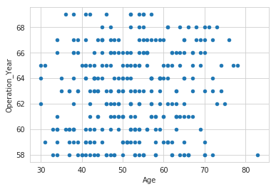

```python
# FIRST WE WILL PLOT THE SCATTER PLOT TO SEE
haberman_data.plot(kind="scatter",x="Age",y="Operation_Year")
plt.show() # cannot make much sense out of this , can't tell which point belong to which survival status
```

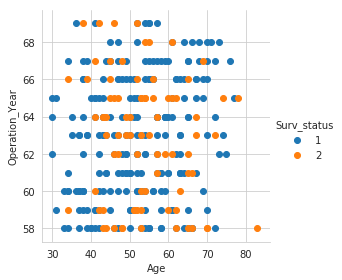

```python
# using color coding to see if anything comes out
import seaborn as sns
sns.set_style("whitegrid")
sns.FacetGrid(haberman_data,hue="Surv_status",size=4).map(plt.scatter,"Age","Operation_Year").add_legend();
plt.show();
```

**Observations:**

1. Age and Operation Year can't seperate the survival status of the patients
2. Seperation of Survival Status is difficult as their is lot of overlap

# Try With Pair Plot

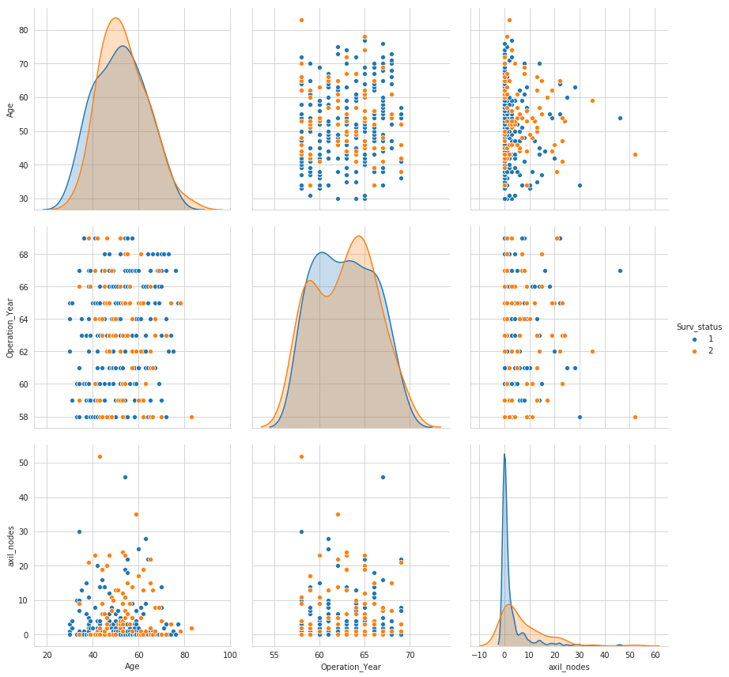

```python
#close the already shown plot
plt.close()
sns.set_style("whitegrid")
sns.pairplot(haberman_data,hue="Surv_status",size=4,vars=['Age', 'Operation_Year', 'axil_nodes']),
plt.show()
```

**Observations:**

1. Pairplot is not able to distinguish the data
2. We are not able to distinguish the class using the two feature at a time and hence bivariate analysis is not helpful

```python
# We will now seprate the data on the bases on the class and will apply some variable based visualisation
# class 1 and class data seperation
class1_data = haberman_data.loc[haberman_data["Surv_status"]==1]
class2_data = haberman_data.loc[haberman_data["Surv_status"]==2]

print("People Who Survived 5 Years and More")
class1_data.describe()
```

```
People Who Survived 5 Years and More
```

|  | Age | Operation_Year | axil_nodes | Surv_status |
| --- | --- | --- | --- | --- |
| count | 225.000000 | 225.000000 | 225.000000 | 225.0 |
| mean | 52.017778 | 62.862222 | 2.791111 | 1.0 |
| std | 11.012154 | 3.222915 | 5.870318 | 0.0 |
| min | 30.000000 | 58.000000 | 0.000000 | 1.0 |
| 25% | 43.000000 | 60.000000 | 0.000000 | 1.0 |
| 50% | 52.000000 | 63.000000 | 0.000000 | 1.0 |
| 75% | 60.000000 | 66.000000 | 3.000000 | 1.0 |
| max | 77.000000 | 69.000000 | 46.000000 | 1.0 |

```python
print("People Who Survived 5 Years and less")
class2_data.describe()
```

```
People Who Survived 5 Years and less
```

|  | Age | Operation_Year | axil_nodes | Surv_status |
| --- | --- | --- | --- | --- |
| count | 81.000000 | 81.000000 | 81.000000 | 81.0 |
| mean | 53.679012 | 62.827160 | 7.456790 | 2.0 |
| std | 10.167137 | 3.342118 | 9.185654 | 0.0 |
| min | 34.000000 | 58.000000 | 0.000000 | 2.0 |
| 25% | 46.000000 | 59.000000 | 1.000000 | 2.0 |
| 50% | 53.000000 | 63.000000 | 4.000000 | 2.0 |
| 75% | 61.000000 | 65.000000 | 11.000000 | 2.0 |
| max | 83.000000 | 69.000000 | 52.000000 | 2.0 |

**#Observations**

1. Age and Operation Year are not changing that much in both the classes statistics and have almost same values in both the sets , the variable that is changing is axillary nodes in both the classes
2. If we see the survived patients then 75 % of the patients have axillary nodes values <= 3 In case of the patients of class 2 who died 75% of the patients have axillary nodes values <=11
3. If wee see the axil_nodes max values than in case of survived patients it is 46 and in case of dead patients it is 52 means . Alone axil_nodes values can't decide the survival as there are cases of axil_nodes values = 1 but  
   still they didn' survived

# Univariate Analysis

```python
# We will analyse the data based on one feature
```

# 1-D Scatter plots

```python
# we will draw 1-D Scatter plot on the Auxillary Nodes data points
```

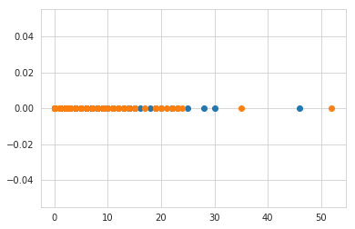

```python
# Using axil_nodes for 1-D scatter plot as we know it changes marginally
plt.plot(class1_data["axil_nodes"],np.zeros_like(class1_data["axil_nodes"]),'o')
plt.plot(class2_data["axil_nodes"],np.zeros_like(class2_data["axil_nodes"]),'o')
plt.show()
```

**#Observations**

1. Hard to make sense from the plot because points are overlapping each other

# Using Only One Feature (Univariate Based Analysis)

```python
# we will use Histogram , PDF , CDF to Analyse the data of the patients
```

# 1. Using Age Feature

# Histogram

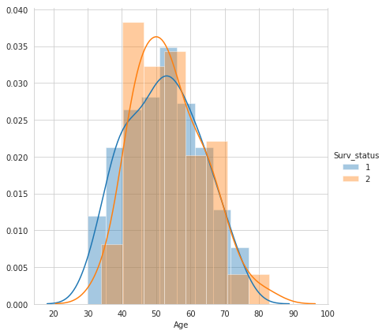

```python
sns.set_style("whitegrid")
sns.FacetGrid(haberman_data,hue="Surv_status",size=6).map(sns.distplot,"Age").add_legend();
plt.show();
```

# PDF AND CDF Using Age

```python
counts,bin_edges = np.histogram(class1_data["Age"],bins=10,density=True)
```

```python
counts # shows the no of pdf values for each bin
```

```
array([0.01134752, 0.02269504, 0.02647754, 0.01985816, 0.03498818,
       0.03498818, 0.01985816, 0.02364066, 0.01323877, 0.00567376])
```

```python
bin_edges
```

```
array([30. , 34.7, 39.4, 44.1, 48.8, 53.5, 58.2, 62.9, 67.6, 72.3, 77. ])
```

```python
print(len(counts))
print(len(bin_edges)) # need to start from the second
```

```
10
11
```

```
For Class : 1
[0.05333333 0.10666667 0.12444444 0.09333333 0.16444444 0.16444444
 0.09333333 0.11111111 0.06222222 0.02666667]
[30.  34.7 39.4 44.1 48.8 53.5 58.2 62.9 67.6 72.3 77. ]

 For Class 2 :
[0.03703704 0.12345679 0.19753086 0.19753086 0.13580247 0.12345679
 0.09876543 0.04938272 0.02469136 0.01234568]
[34.  38.9 43.8 48.7 53.6 58.5 63.4 68.3 73.2 78.1 83. ]
```

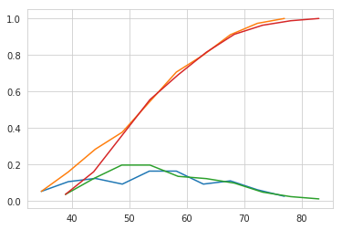

```python
pdf = counts/sum(counts)
print("\nFor Class : 1")
print(pdf)
print(bin_edges)
cdf = np.cumsum(pdf)
plt.plot(bin_edges[1:],pdf)
plt.plot(bin_edges[1:],cdf)



# plot for class 2
counts,bin_edges = np.histogram(class2_data["Age"],bins=10,density=True)
pdf = counts/sum(counts)
print("\n For Class 2 : ")
print(pdf)
print(bin_edges)
cdf = np.cumsum(pdf)
plt.plot(bin_edges[1:],pdf)
plt.plot(bin_edges[1:],cdf)
plt.show()
```

# Using Box Plot

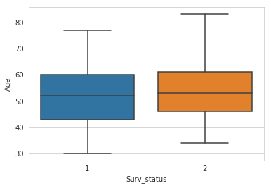

```python
# Box plot on the Age Feature
sns.boxplot(x="Surv_status",y="Age",data=haberman_data)
plt.show()
# 25th , 50th , 75th percentile are overlapping each other not able to distinguish
```

# Violin Plot

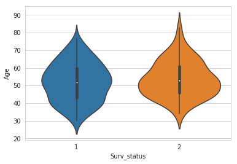

```python
sns.violinplot(x="Surv_status",y="Age",data=haberman_data)
plt.show()
# same problem of overlapping in the percentiles
```

**#Final Ovservations:**

1. Age plots are almost same for both the classes 1 and 2.
2. There is lot of overlapping in maximum plots when we draw it using the Patient Age
3. This show that Patient Age can't be used for classification into the two ages
4. Patient Age doesn't affect the survival status of the patient to that extent.

# 2. Using Operation Year Feature

# Histogram

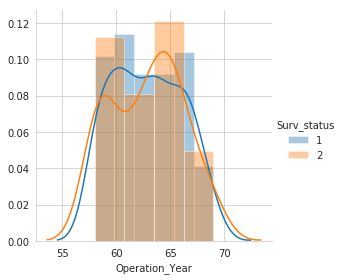

```python
sns.set_style("whitegrid")
sns.FacetGrid(haberman_data,hue="Surv_status",size=4).map(sns.distplot,"Operation_Year").add_legend();
plt.show();
```

# CDF and PDF

```
For Class : 1
[0.18666667 0.10666667 0.10222222 0.07111111 0.09777778 0.10222222
 0.06666667 0.09777778 0.09333333 0.07555556]
[58.  59.1 60.2 61.3 62.4 63.5 64.6 65.7 66.8 67.9 69. ]

 For Class 2 :
[0.25925926 0.04938272 0.03703704 0.08641975 0.09876543 0.09876543
 0.16049383 0.07407407 0.04938272 0.08641975]
[58.  59.1 60.2 61.3 62.4 63.5 64.6 65.7 66.8 67.9 69. ]
```

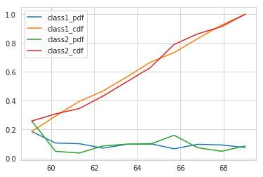

```python
counts,bin_edges = np.histogram(class1_data["Operation_Year"],bins=10,density=True)
pdf = counts/sum(counts)
print("\nFor Class : 1")
print(pdf)
print(bin_edges)
cdf = np.cumsum(pdf)
plt.plot(bin_edges[1:],pdf)
plt.plot(bin_edges[1:],cdf)



# plot for class 2
counts,bin_edges = np.histogram(class2_data["Operation_Year"],bins=10,density=True)
pdf = counts/sum(counts)
print("\n For Class 2 : ")
print(pdf)
print(bin_edges)
cdf = np.cumsum(pdf)
plt.plot(bin_edges[1:],pdf)
plt.plot(bin_edges[1:],cdf)
plt.legend(["class1_pdf","class1_cdf","class2_pdf","class2_cdf"])
plt.show()
```

# Bos Plot Using the Operation Year

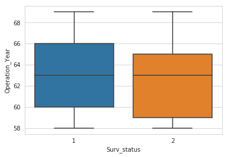

```python
sns.set_style("whitegrid")
sns.boxplot(x="Surv_status",y="Operation_Year",data=haberman_data);
```

# Violin Plot

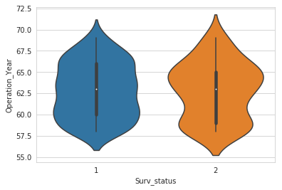

```python
sns.violinplot(x="Surv_status",y="Operation_Year",data=haberman_data);
```

**#Final Observations:**

1. Operation Year doesn't affect the survival status of the patient upto that extent
2. Histogram , CDF , PDF, Box , Violin Plots are not able to classify and seperate the data becuase of overlapping
3. Operation year cannot be considered as the important feature in the haberman data set.

# 3 . Using the Axillary Nodes Values

# Histogram

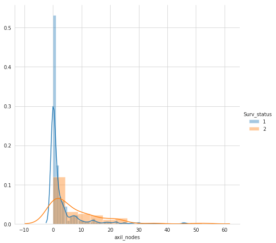

```python
# using the axil_nodes column values now
import warnings;
warnings.simplefilter('ignore')
sns.set_style("whitegrid")
sns.FacetGrid(haberman_data,hue="Surv_status",height=7).map(sns.distplot,"axil_nodes").add_legend();
plt.show();
```

# PDF , CDF Using Axillary Nodes

```
For Class : 1
[0.83555556 0.08       0.02222222 0.02666667 0.01777778 0.00444444
 0.00888889 0.         0.         0.00444444]
[ 0.   4.6  9.2 13.8 18.4 23.  27.6 32.2 36.8 41.4 46. ]

 For Class 2 :
[0.56790123 0.14814815 0.13580247 0.04938272 0.07407407 0.
 0.01234568 0.         0.         0.01234568]
[ 0.   5.2 10.4 15.6 20.8 26.  31.2 36.4 41.6 46.8 52. ]
```

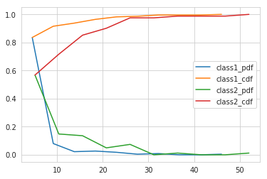

```python
counts,bin_edges = np.histogram(class1_data["axil_nodes"],bins=10,density=True)
pdf = counts/sum(counts)
print("\nFor Class : 1")
print(pdf)
print(bin_edges)
cdf = np.cumsum(pdf)
plt.plot(bin_edges[1:],pdf)
plt.plot(bin_edges[1:],cdf)



# plot for class 2
counts,bin_edges = np.histogram(class2_data["axil_nodes"],bins=10,density=True)
pdf = counts/sum(counts)
print("\n For Class 2 : ")
print(pdf)
print(bin_edges)
cdf = np.cumsum(pdf)
plt.plot(bin_edges[1:],pdf)
plt.plot(bin_edges[1:],cdf)
plt.legend(["class1_pdf","class1_cdf","class2_pdf","class2_cdf"])
plt.show()
```

# Box Plots

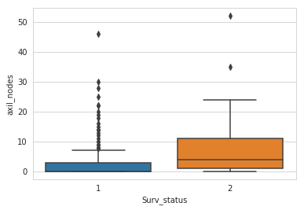

```python
sns.boxplot(x="Surv_status",y="axil_nodes",data=haberman_data)
plt.show()
```

```python
# some percentage calculation on the dat sets

print("\nPercentage of the patients having 0 axillary nodes counts : {} %"
     .format((len(haberman_data[haberman_data["axil_nodes"]==0])/len(haberman_data)) *100))

print("\nPercentage of the patients having  axillary nodes counts < 3 : {} %"
     .format((len(haberman_data[haberman_data["axil_nodes"]<=3])/len(haberman_data)) *100))

print("\nPercentage of the patients having  axillary nodes counts > 3 and less 10 : {} %"
     .format((len(haberman_data[(haberman_data["axil_nodes"]>3) & (haberman_data["axil_nodes"]<10)])/len(haberman_data)) *100))

print("\nPercentage of the patients having  axillary nodes counts less 10 : {} %"
     .format((len(haberman_data[haberman_data["axil_nodes"]<10])/len(haberman_data)) *100))

print("\nPercentage of the patients having  axillary nodes counts > 10 : {} %"
     .format((len(haberman_data[haberman_data["axil_nodes"]>10])/len(haberman_data)) *100))
```

```
Percentage of the patients having 0 axillary nodes counts : 44.44444444444444 %

Percentage of the patients having  axillary nodes counts < 3 : 70.91503267973856 %

Percentage of the patients having  axillary nodes counts > 3 and less 10 : 15.032679738562091 %

Percentage of the patients having  axillary nodes counts less 10 : 85.94771241830065 %

Percentage of the patients having  axillary nodes counts > 10 : 13.071895424836603 %
```

```python
# some percentage calculation on the data sets

print("\nPercentage of the patients having 0 auxillary nodes counts and survival status 1 : {} %"
     .format((len(haberman_data[(haberman_data["axil_nodes"]==0) &(haberman_data["Surv_status"]==1)])/len(haberman_data)) *100))

print("\nPercentage of the patients having  auxillary nodes counts < 3 and survival status 1 : {} %"
     .format((len(haberman_data[haberman_data["axil_nodes"]<=3 & (haberman_data["Surv_status"]==1)])/len(haberman_data)) *100))

print("\nPercentage of the patients having  auxillary nodes counts > 3 and less 10 and class 1 : {} %"
     .format((len(haberman_data[(haberman_data["axil_nodes"]>3) & (haberman_data["axil_nodes"]<10) & (haberman_data["Surv_status"]==1)])/len(class1_data)) *100))
```

```
Percentage of the patients having 0 auxillary nodes counts and survival status 1 : 38.23529411764706 %

Percentage of the patients having  auxillary nodes counts < 3 and survival status 1 : 55.22875816993464 %

Percentage of the patients having  auxillary nodes counts > 3 and less 10 and class 1 : 12.444444444444445 %
```

```python
# some percentage calculation on the data sets

print("\nPercentage of the patients having 0 axillary nodes counts and survival status 2 : {} %"
     .format((len(haberman_data[(haberman_data["axil_nodes"]==0) &(haberman_data["Surv_status"]==2)])/len(haberman_data)) *100))

print("\nPercentage of the patients having  axillary nodes counts < 3 and survival status 2 : {} %"
     .format((len(haberman_data[haberman_data["axil_nodes"]<=3 & (haberman_data["Surv_status"]==2)])/len(haberman_data)) *100))

print("\nPercentage of the patients having  axillary nodes counts > 3 and less 10 and class 2 : {} %"
     .format((len(haberman_data[(haberman_data["axil_nodes"]>3) & (haberman_data["axil_nodes"]<10) & (haberman_data["Surv_status"]==2)])/len(class1_data)) *100))

print("\nPercentage of the patients having  axillary nodes counts >10 and survival status 2 : {} %"
     .format((len(haberman_data[haberman_data["axil_nodes"]>10 & (haberman_data["Surv_status"]==2)])/len(haberman_data)) *100))
```

```
Percentage of the patients having 0 axillary nodes counts and survival status 2 : 6.209150326797386 %

Percentage of the patients having  axillary nodes counts < 3 and survival status 2 : 47.05882352941176 %

Percentage of the patients having  axillary nodes counts > 3 and less 10 and class 2 : 8.0 %

Percentage of the patients having  axillary nodes counts >10 and survival status 2 : 55.55555555555556 %
```

# Violin Plot

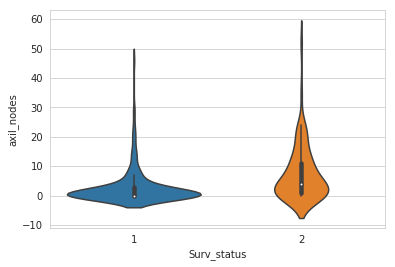

```python
sns.violinplot(x="Surv_status",y="axil_nodes",data=haberman_data)
plt.show()
```

```python
class1_data.describe()
```

|  | Age | Operation_Year | axil_nodes | Surv_status |
| --- | --- | --- | --- | --- |
| count | 225.000000 | 225.000000 | 225.000000 | 225.0 |
| mean | 52.017778 | 62.862222 | 2.791111 | 1.0 |
| std | 11.012154 | 3.222915 | 5.870318 | 0.0 |
| min | 30.000000 | 58.000000 | 0.000000 | 1.0 |
| 25% | 43.000000 | 60.000000 | 0.000000 | 1.0 |
| 50% | 52.000000 | 63.000000 | 0.000000 | 1.0 |
| 75% | 60.000000 | 66.000000 | 3.000000 | 1.0 |
| max | 77.000000 | 69.000000 | 46.000000 | 1.0 |

```python
class2_data.describe()
```

|  | Age | Operation_Year | axil_nodes | Surv_status |
| --- | --- | --- | --- | --- |
| count | 81.000000 | 81.000000 | 81.000000 | 81.0 |
| mean | 53.679012 | 62.827160 | 7.456790 | 2.0 |
| std | 10.167137 | 3.342118 | 9.185654 | 0.0 |
| min | 34.000000 | 58.000000 | 0.000000 | 2.0 |
| 25% | 46.000000 | 59.000000 | 1.000000 | 2.0 |
| 50% | 53.000000 | 63.000000 | 4.000000 | 2.0 |
| 75% | 61.000000 | 65.000000 | 11.000000 | 2.0 |
| max | 83.000000 | 69.000000 | 52.000000 | 2.0 |

**#Observations**

**#Further Observations:**

1. As we have seen that axillary nodes can classify the data upto some extent .
2. We can see the data points of axillary nodes and age so that we can find somethings to classify

```python
# points where the age is less than 35 and count of auxil_nodes count <=3 and survived
print("Patients whose age < 40 and axil_nodes <=3 among the whole data set : {}"
      .format(len(haberman_data[(haberman_data["Age"]<40) & (haberman_data["axil_nodes"]<=3)])))

print("Patients whose age > 40 and axil_nodes <=3 among the whole data set : {}"
      .format(len(haberman_data[(haberman_data["Age"]>40) & (haberman_data["axil_nodes"]<=3)])))

print("Patients whose age > 40 and axil_nodes <=3 among 225 data points for class 1 : {}"
      .format(len(class1_data[(class1_data["Age"]>40) & (class1_data["axil_nodes"]<=3)])))
```

```
Patients whose age < 40 and axil_nodes <=3 among the whole data set : 27
Patients whose age > 40 and axil_nodes <=3 among the whole data set : 187
Patients whose age > 40 and axil_nodes <=3 among 225 data points for class 1 : 150
```

```python
# points where the age is less than 35 and count of auxil_nodes count <=3 and survived
print("Patients whose age > 40 and axil_nodes < 3 among the whole data set : {}"
      .format(len(haberman_data[(haberman_data["Age"]>40) & (haberman_data["axil_nodes"]<3)])))

print("Patients whose age > 40 and axil_nodes >3 among the whole data set : {}"
      .format(len(haberman_data[(haberman_data["Age"]>40) & (haberman_data["axil_nodes"]>3)])))

print("Patients whose age > 40 and axil_nodes > 3 among 225 data points for class 1 : {}"
      .format(len(class1_data[(class1_data["Age"]>40) & (class1_data["axil_nodes"]>3)])))
```

```
Patients whose age > 40 and axil_nodes < 3 among the whole data set : 169
Patients whose age > 40 and axil_nodes >3 among the whole data set : 76
Patients whose age > 40 and axil_nodes > 3 among 225 data points for class 1 : 36
```

# Contour Plot

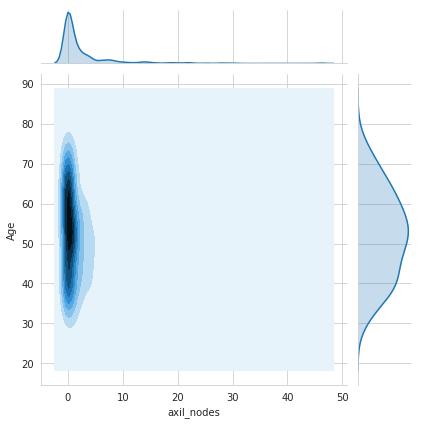

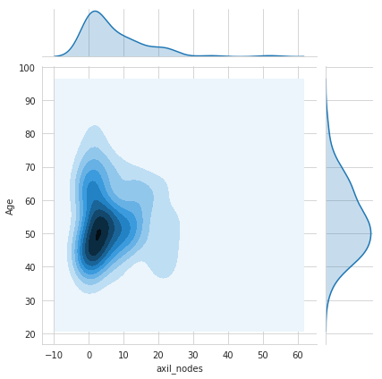

```python
sns.jointplot(x="axil_nodes",y="Age",data=class1_data,kind="kde")

plt.show()
sns.jointplot(x="axil_nodes",y="Age",data=class2_data,kind="kde")

plt.show()
```

**#Observations**

1. Contour plots didn't tell much about the the class :
2. But we can see that most of points in the class 1 have axil_nodes < 3 and
3. In case of class 2 most of the points are having axil_nodes > 3

# FINAL CONCLUSION

**# Final Observations:**

1. Age and Year of Operation is not a deciding feature for classification
2. Smaller the no of the positive axillary nodes higher the survival chances.
3. Larger the positive axillary nodes count the chances of survival of the patient decreases . But there are some cases  
   that also tell that smaller the axillary count doesn't make sure the survival of the patient as patients woth 0 axillary counts were not able to survive for more than 5 years.
4. From the data analysis we can say that

   ```
   if positive axillary nodes < 3 its class is 1
   if age > 40 and positive axillary nodes < 3 chances are that it can lie in class 1 fewer chances for it to lie
   in class 2
   ```

5. There can be mistakes in clasifying the data and chances are higher.
6. Classification with these feature is a difficult task and can misclassify for a particular data point